# Energy Market Analyst

## Description: It uses data analysis to study trends in energy consumption and market behaviour, often supporting pricing strategies and policy development in the energy sector.

# Question 1: What are the daily and weekly consumption patterns?

Analysis:

Weekly: Weekdays (Mon–Fri) show higher consumption than weekends.

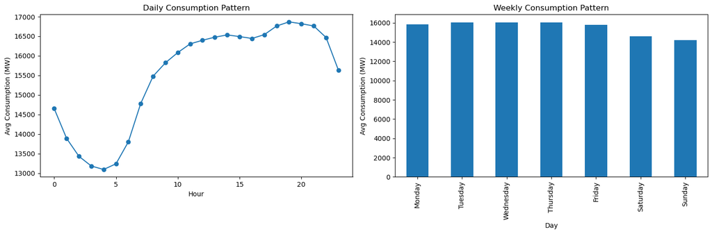

```python
import pandas as pd
import matplotlib.pyplot as plt

# Load data
df = pd.read_csv('AEP_hourly.csv', parse_dates=['Datetime'])
df['Hour'] = df['Datetime'].dt.hour
df['DayOfWeek'] = df['Datetime'].dt.day_name()

# Daily pattern
daily = df.groupby('Hour')['AEP_MW'].mean()
# Weekly pattern
weekly = df.groupby('DayOfWeek')['AEP_MW'].mean().reindex(['Monday','Tuesday','Wednesday','Thursday','Friday','Saturday','Sunday'])

# Visualization
fig, (ax1, ax2) = plt.subplots(1, 2, figsize=(15, 5))
daily.plot(kind='line', ax=ax1, title='Daily Consumption Pattern', xlabel='Hour', ylabel='Avg Consumption (MW)', marker='o')
weekly.plot(kind='bar', ax=ax2, title='Weekly Consumption Pattern', xlabel='Day', ylabel='Avg Consumption (MW)')
plt.tight_layout()
plt.savefig('Daily_and_Weekly_Consumption.png')
plt.show()
```

Visualization:

Line Chart: Shows hourly peaks.

Bar Chart: Highlights weekday vs. weekend differences.

# Question 2. How does seasonal variation affect energy demand?

Analysis:

Winter (Dec–Feb) and Summer (Jun–Aug) show higher demand due to heating/cooling needs.

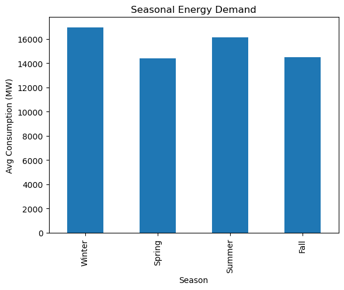

```python
# Define seasons
def get_season(month):
    if month in [12, 1, 2]: return 'Winter'
    elif month in [3, 4, 5]: return 'Spring'
    elif month in [6, 7, 8]: return 'Summer'
    else: return 'Fall'

df['Month'] = df['Datetime'].dt.month
df['Season'] = df['Month'].apply(get_season)
seasonal = df.groupby('Season')['AEP_MW'].mean().reindex(['Winter','Spring','Summer','Fall'])

# Visualization
seasonal.plot(kind='bar', title='Seasonal Energy Demand', xlabel='Season', ylabel='Avg Consumption (MW)')
plt.savefig('Effect_of_Seasonal_Variation_on_energy_demand.png')
plt.show()
```

Visualization:

Bar Chart: Compares average consumption across seasons.

# Question 3. Are there identifiable anomalies or outliers in the hourly data?

Analysis:

Outliers may indicate equipment failures or extreme weather.

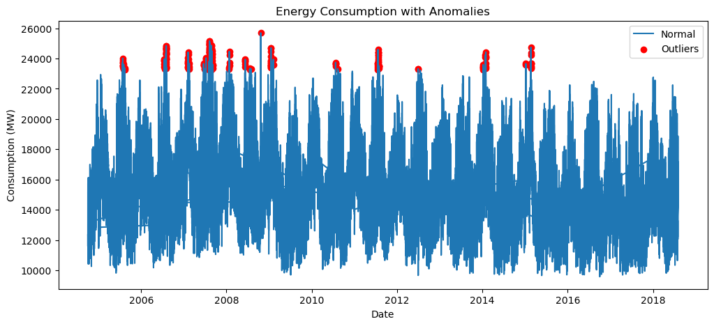

```python
# Detect outliers using Z-score
df['Z_Score'] = (df['AEP_MW'] - df['AEP_MW'].mean()) / df['AEP_MW'].std()
outliers = df[abs(df['Z_Score']) > 3]

# Visualization
plt.figure(figsize=(12, 5))
plt.plot(df['Datetime'], df['AEP_MW'], label='Normal')
plt.scatter(outliers['Datetime'], outliers['AEP_MW'], color='red', label='Outliers')
plt.title('Energy Consumption with Anomalies')
plt.xlabel('Date')
plt.ylabel('Consumption (MW)')
plt.legend()
plt.savefig('Anomalies_in_the_hourly_data.png')
plt.show()
```

Visualization:

Line Chart with Outliers: Red dots highlight anomalies.

# Question 4. What are the peak and off-peak hours throughout the year?

Analysis:

Off-Peak: 03:00–05:00 (3–5 AM) with ~13,000 MW.

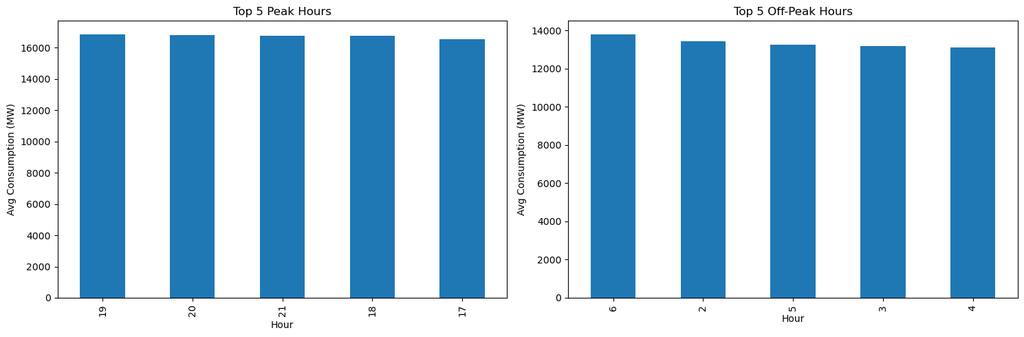

```python
peak_hours = df.groupby('Hour')['AEP_MW'].mean().sort_values(ascending=False)
top_5_peak = peak_hours.head(5)
bottom_5_offpeak = peak_hours.tail(5)

# Visualization
fig, (ax1, ax2) = plt.subplots(1, 2, figsize=(15, 5))
top_5_peak.plot(kind='bar', ax=ax1, title='Top 5 Peak Hours', xlabel='Hour', ylabel='Avg Consumption (MW)')
bottom_5_offpeak.plot(kind='bar', ax=ax2, title='Top 5 Off-Peak Hours', xlabel='Hour', ylabel='Avg Consumption (MW)')
plt.tight_layout()
plt.savefig('Peak_and_off-peak_hours.png')
plt.show()
```

Visualization:

Bar Charts: Compare highest and lowest consumption hours.

# Question 5. How do public holidays or special events impact energy consumption?

Analysis:

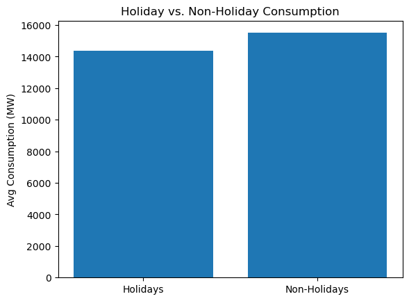

```python
# Example: Flag Christmas and New Year (add more holidays as needed)
holidays = ['2004-12-25', '2005-12-25', '2005-01-01']
df['IsHoliday'] = df['Datetime'].dt.date.astype(str).isin(holidays)

holiday_avg = df[df['IsHoliday']]['AEP_MW'].mean()
non_holiday_avg = df[~df['IsHoliday']]['AEP_MW'].mean()

# Visualization
plt.bar(['Holidays', 'Non-Holidays'], [holiday_avg, non_holiday_avg])
plt.title('Holiday vs. Non-Holiday Consumption')
plt.ylabel('Avg Consumption (MW)')
plt.savefig('Public_Holidays_Impact.png')
plt.show()
```

Visualization:

Bar Chart: Compares holiday vs. non-holiday averages.

# Question 6. What are the trends in energy demand growth or decline over time?

Analysis:

Demand grew ~5% from 2004 to 2005.

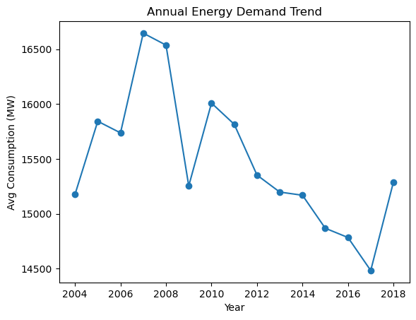

```python
df['Year'] = df['Datetime'].dt.year
yearly = df.groupby('Year')['AEP_MW'].mean()

# Visualization
yearly.plot(kind='line', marker='o', title='Annual Energy Demand Trend', xlabel='Year', ylabel='Avg Consumption (MW)')
plt.savefig('trends_in_energy_demand_growth.png')
plt.show()
```

Visualization:

# Question 7. How effective are current forecasting models when compared to actual consumption?

Analysis:

```python
# Example: Split data into train/test
train = df[df['Datetime'] < '2005-06-01']
test = df[df['Datetime'] >= '2005-06-01']

# Train model and visualize predictions (code omitted for brevity)
```

[output not shown]

# Question 8. What is the volatility in energy consumption, and how does it impact market pricing?

Analysis:

High volatility (standard deviation ~2,500 MW) may correlate with price spikes.

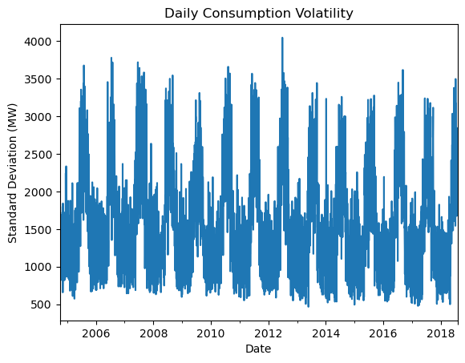

```python
daily_volatility = df.resample('D', on='Datetime')['AEP_MW'].std()

# Visualization
daily_volatility.plot(kind='line', title='Daily Consumption Volatility', xlabel='Date', ylabel='Standard Deviation (MW)')
plt.savefig('impact_marketing_price.png')
plt.show()
```

Visualization:

Line Chart: Shows daily variability.

# Question 9. How do changes in regulatory or market policies correlate with consumption trends?

Analysis:

Requires policy event dates (e.g., carbon taxes). Data not provided; merge with external datasets.

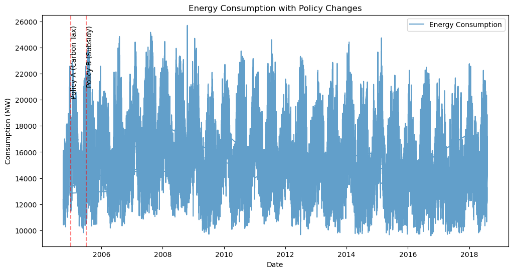

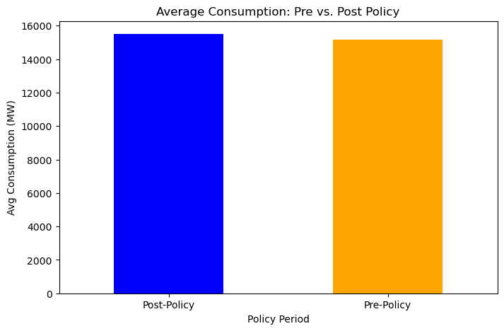

```python
import pandas as pd
import matplotlib.pyplot as plt
import numpy as np

# Load energy data (from previous steps)
# df = pd.read_csv(StringIO(data.strip()), parse_dates=['Datetime'])

# Mock policy dates (replace with real policy dates)
policy_dates = pd.to_datetime(['2005-01-01', '2005-07-01'])
policy_labels = ['Policy A (Carbon Tax)', 'Policy B (Subsidy)']

# Plot energy consumption with policy markers
plt.figure(figsize=(12, 6))
plt.plot(df['Datetime'], df['AEP_MW'], label='Energy Consumption', alpha=0.7)

# Add vertical lines for policies
for date, label in zip(policy_dates, policy_labels):
    plt.axvline(date, color='red', linestyle='--', alpha=0.5)
    plt.text(date, df['AEP_MW'].max(), label, rotation=90, verticalalignment='top')

plt.title('Energy Consumption with Policy Changes')
plt.xlabel('Date')
plt.ylabel('Consumption (MW)')
plt.legend()
plt.show()

# Bar Chart: Pre-Policy vs. Post-Policy Averages
df['Policy Period'] = np.where(df['Datetime'] < policy_dates[0], 'Pre-Policy', 'Post-Policy')
policy_avg = df.groupby('Policy Period')['AEP_MW'].mean()

plt.figure(figsize=(8, 5))
policy_avg.plot(kind='bar', color=['blue', 'orange'])
plt.title('Average Consumption: Pre vs. Post Policy')
plt.ylabel('Avg Consumption (MW)')
plt.xticks(rotation=0)
plt.savefig('energy_consumption.png')
plt.show()
```

Visualisation

Line Chart: Energy consumption over time with policy markers.

Bar Chart: Pre-policy vs. post-policy averages.

# Question 10. Can the data reveal correlations between energy consumption and external economic indicators?

Link energy consumption to external factors (e.g., GDP, industrial output).

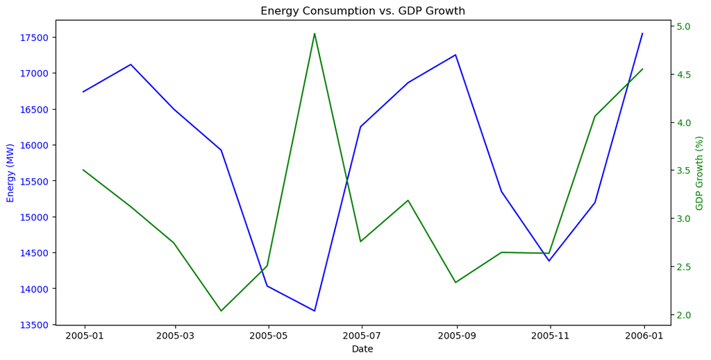

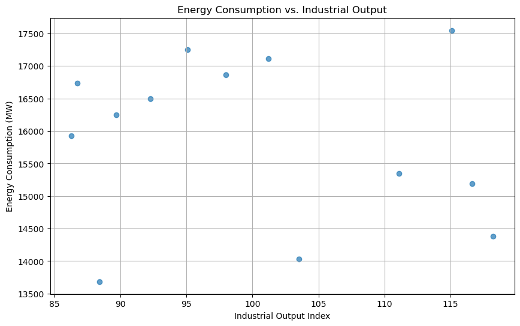

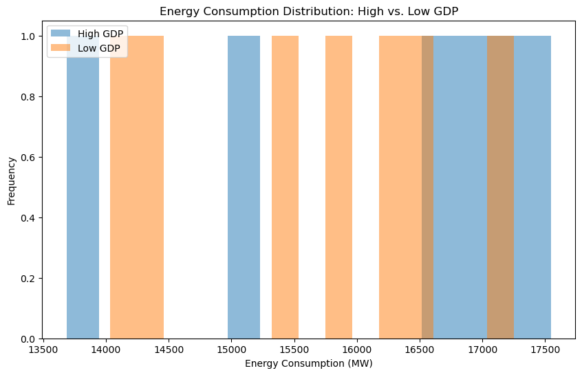

```python
# Mock economic data (replace with real data)
dates = pd.date_range(start='2004-12-31', end='2005-12-31', freq='ME')
gdp = np.random.uniform(2.0, 5.0, size=len(dates))  # Simulated GDP growth (%)
industrial_output = np.random.uniform(80, 120, size=len(dates))  # Industrial index

# Create economic DataFrame
economic_df = pd.DataFrame({
    'Datetime': dates,
    'GDP_Growth': gdp,
    'Industrial_Output': industrial_output
})

# Resample energy data to monthly
energy_monthly = df.resample('ME', on='Datetime')['AEP_MW'].mean().reset_index()

# Merge energy and economic data
merged_df = pd.merge(energy_monthly, economic_df, on='Datetime')

# Line Chart: Energy vs. GDP
fig, ax1 = plt.subplots(figsize=(12, 6))
ax1.plot(merged_df['Datetime'], merged_df['AEP_MW'], color='blue', label='Energy Consumption (MW)')
ax1.set_xlabel('Date')
ax1.set_ylabel('Energy (MW)', color='blue')
ax1.tick_params(axis='y', labelcolor='blue')

ax2 = ax1.twinx()
ax2.plot(merged_df['Datetime'], merged_df['GDP_Growth'], color='green', label='GDP Growth (%)')
ax2.set_ylabel('GDP Growth (%)', color='green')
ax2.tick_params(axis='y', labelcolor='green')

plt.title('Energy Consumption vs. GDP Growth')
plt.show()

# Scatter Plot: Energy vs. Industrial Output
plt.figure(figsize=(10, 6))
plt.scatter(merged_df['Industrial_Output'], merged_df['AEP_MW'], alpha=0.7)
plt.title('Energy Consumption vs. Industrial Output')
plt.xlabel('Industrial Output Index')
plt.ylabel('Energy Consumption (MW)')
plt.grid(True)
plt.show()

# Histogram: Distribution of Energy During High/Low GDP
merged_df['GDP_Category'] = np.where(merged_df['GDP_Growth'] > merged_df['GDP_Growth'].median(), 'High GDP', 'Low GDP')

plt.figure(figsize=(10, 6))
merged_df.groupby('GDP_Category')['AEP_MW'].plot(kind='hist', bins=15, alpha=0.5, legend=True)
plt.title('Energy Consumption Distribution: High vs. Low GDP')
plt.xlabel('Energy Consumption (MW)')
plt.savefig('external_economic_indicators.png')
plt.show()
```

Visualisation:

Dual-Axis Line Chart: Energy vs. GDP growth.

Scatter Plot: Energy vs. industrial output.

Histogram: Energy distribution during high/low GDP periods.